# 5.4 Named_Entity_Disambiguation

### Named Entity Disambiguation

- **Introduction to NER DisAmbiguator**
- **Spark2.3 Set Up**
- **NER Disambiguation**

### Introduction to NER Disambiguation

**Named Entity Disambiguation** is the task of mapping words of interest, such as names of persons, locations and companies, from an input text document to corresponding unique entities in a target Knowledge Base (KB). Words of interest are called Named Entities (NEs), mentions, or surface forms.

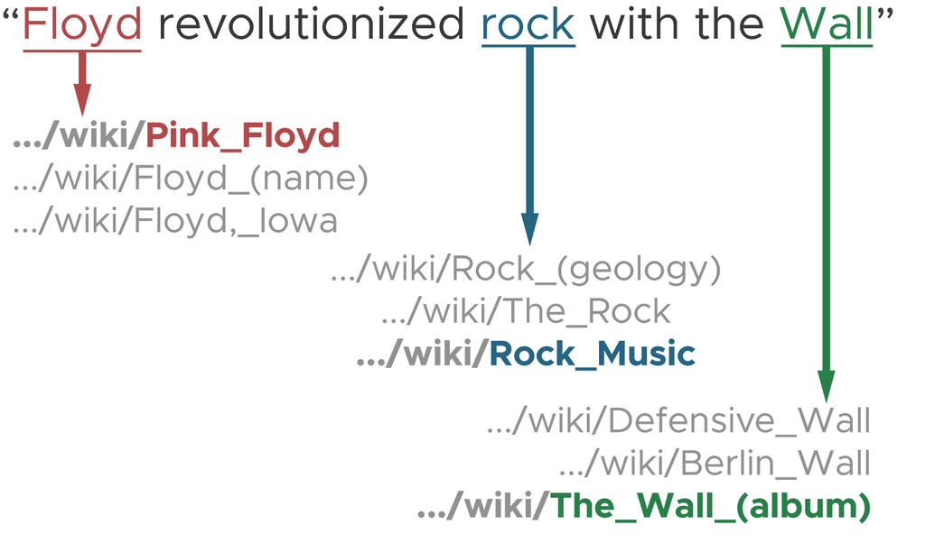

**NER Disambiguation model is built on top of NER model, which resolves the ambiguation based on the context.**

### License Setup

```python
#importing json file that contains license details (it is provided by SparkNLP)
import json
import sys
import os
with open('/dfs/is/home/m292915/spark_nlp/data/license_keys.json',encoding='utf-8-sig') as f:
    license_keys = json.load(f)
#adding license keys to system enivironment variables list
os.environ['SPARK_NLP_LICENSE'] = license_keys['SPARK_NLP_LICENSE']
os.environ['SPARK_OCR_LICENSE'] = license_keys['SPARK_OCR_LICENSE']
os.environ['AWS_ACCESS_KEY_ID']= license_keys['AWS_ACCESS_KEY_ID']
os.environ['AWS_SECRET_ACCESS_KEY'] = license_keys['AWS_SECRET_ACCESS_KEY']
#add sparknlp library location path to system paths.
sys.path.append('/dfs/is/home/m292915/.conda/envs/sparknlp/lib/python3.7/site-packages')
```

### Spark Set Up

```python
#loading jar path
from utils import pathbuilder
jar_path=pathbuilder.load_jarpath()

#initializing spark session
from pyspark.sql import SparkSession
spark = SparkSession.builder \
        .appName("Spark NLP") \
        .master("local[*]") \
        .config("spark.driver.memory", "16G") \
        .config("spark.serializer", "org.apache.spark.serializer.KryoSerializer") \
        .config("spark.kryoserializer.buffer.max", "1000M") \
        .config("spark.driver.maxResultSize", "0")\
        .config("spark.jars", "{}spark-nlp-spark23-assembly-2.6.2.jar,{}spark-nlp-jsl-2.6.2-spark23.jar".format(jar_path,jar_path)) \
        .getOrCreate()

#importing dependencies
import sparknlp
from sparknlp.pretrained import PretrainedPipeline
from sparknlp.annotator import *
from sparknlp_jsl.annotator import *
from sparknlp.base import *
import sparknlp_jsl
import pyspark.sql.functions as f
print('spark NLP version: ',sparknlp.version())
print('spark version:',spark.version)
```

```
spark NLP version:  2.6.2
spark version: 2.3.0
```

```python
# Sample data
text = "The show also had a contestant named Donald Trump " \
               + "who later defeated Christina Aguilera on the way to become Female Vocalist Champion in the 1989 edition of Star Search in the United States. "
data = spark.createDataFrame([
            [text]]) \
            .toDF("text")
```

### NER Disambiguator

```python
#Initializing document assembler
document_assembler = DocumentAssembler()\
  .setInputCol("text")\
  .setOutputCol("document")

# Sentence Detector annotator, processes various sentences per line
sentence_detector = SentenceDetector()\
  .setInputCols(["document"])\
  .setOutputCol("sentence")

# Tokenizer splits words in a relevant format for NLP
tokenizer = Tokenizer()\
  .setInputCols(["sentence"])\
  .setOutputCol("token")

#Loading embeddings models from local disk
word_embeddings = WordEmbeddingsModel.load(pathbuilder.load_pretrained_model_path('glove_100d_en_2.4.0_2.4'))\
     .setInputCols("document",'token')\
     .setOutputCol("embeddings")

#Generation sentence level embeddings
sentence_embeddings = SentenceEmbeddings()\
  .setInputCols("sentence","embeddings")\
  .setOutputCol("sentence_embeddings")

#loading NER DL model from local Disk
ner_model=NerDLModel.load(pathbuilder.load_pretrained_model_path('ner_dl_en_2.4.3_2.4'))\
    .setInputCols(["sentence", "token", "embeddings"])\
    .setOutputCol("ner")

#Initializing NER converter
ner_converter = NerConverter() \
  .setInputCols(["sentence", "token", "ner"]) \
  .setOutputCol("ner_chunk")\
  .setWhiteList(["PER"])

#Initializing NER Disambiguator
disambiguator = NerDisambiguator() \
    .setS3KnowledgeBaseName("i-per") \
    .setInputCols("ner_chunk", "sentence_embeddings") \
    .setOutputCol("disambiguation") \
    .setNumFirstChars(5)

#nlppipeline for disambiguation
nlpPipeline = Pipeline(stages=[
    document_assembler,
    sentence_detector,
    tokenizer,
    word_embeddings,
    sentence_embeddings,
    ner_model,
    ner_converter,
    disambiguator])

empty_data = spark.createDataFrame([[""]]).toDF("text")
model = nlpPipeline.fit(empty_data)
```

```python
result = model.transform(data)
#Since model trying to connect internet to display the results, following error is thrown.
```

[output not shown]

[output cut: 252 more lines]

[output not shown]

```python
#disambiguated.selectExpr("explode(disambiguation)").show(10, False)
```

[output not shown]

## Highlight the entities

```python
from utils import ner_highlighter
```

[output not shown]

```python
ann_text = light_model.fullAnnotate('Peter Parker is a nice persn and lives in New York. Bruce Wayne is also a nice guy and lives in Gotham City.')[0]
ner_highlighter.chunk_highlighter (ann_text[0], entity_column='ner_chunk')
```

[output not shown]

```python
ann_text = light_model.annotate('Peter Parker is a nice persn and lives in New York. Bruce Wayne is also a nice guy and lives in Gotham City.')

ner_highlighter.token_highlighter (ann_text)
```

### References:

Spark NLP offers pre-trained models in 26 languages and all you need to do is to load the pre-trained model into your disk by specifying the model name and then configuring the model parameters as per your use case and dataset. Then you will not need to worry about training a new model from scratch and will be able to enjoy the pre-trained SOTA algorithms directly applied to your own data with transform().

In the official documentation, you can find detailed information regarding how these models are trained by using which algorithms and datasets.

- https://github.com/JohnSnowLabs/spark-nlp-workshop/tree/master/tutorials/Certification_Trainings
- https://github.com/JohnSnowLabs/spark-nlp-models
- https://nlp.johnsnowlabs.com/docs/en/models
- https://nlp.johnsnowlabs.com/docs/en/annotators
- https://nlp.johnsnowlabs.com/docs/en/licensed_annotators